# Отчет по лабораторной работе 6

Власов Артем Сергеевич

Власов Артем Сергеевич

1132246841@rudn.ru

Российский университет дружбы народов

2026-05-02

# Информация

## Докладчик

- Власов Артем Сергеевич
- Студент
- Российский университет дружбы народов им. П. Лумумбы
- 1132246841@rudn.ru
- https://vlasovas52.github.io/ru/

# Выполнение

# Цель работы

# Задание

Выполнить задания с файлами.

# Выполнение лабораторной работы

## 1. Проверка состояния SELinux

SELinux работает в режиме **enforcing** с политикой **targeted**. Это подтверждено с помощью команд `getenforce` и `sestatus`. Режим enforcing означает, что политики SELinux активно применяются и запрещают любые действия, выходящие за их рамки.

## 2. Проверка работы веб-сервера Apache

Веб-сервер Apache запущен и работает корректно. При обращении через браузер к локальному веб-серверу он отвечает на запросы.

## 3. Контекст безопасности процессов Apache

В списке процессов Apache каждому процессу присвоен определенный контекст безопасности SELinux. Этот контекст определяет, к каким ресурсам процесс может получить доступ.

## 4. Переключатели SELinux для Apache

Большинство булевых переключателей SELinux, относящихся к Apache, находятся в положении **off**. Это означает, что дополнительные гибкие настройки доступа для httpd отключены, и сервер работает только в рамках жесткой типизованной политики.

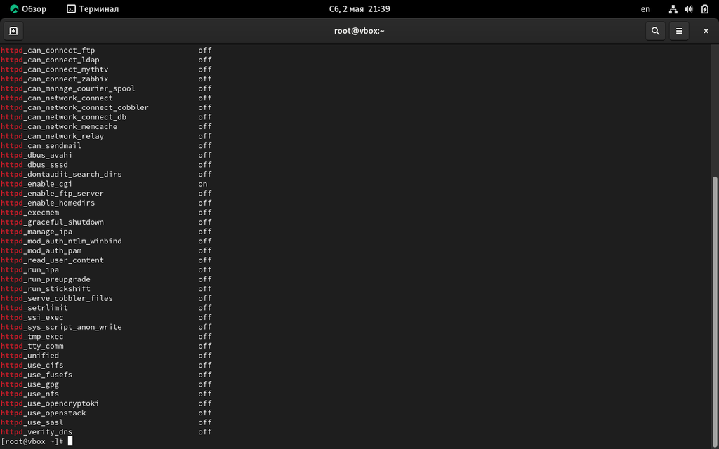

Рисунок 1: Свойства Apache и SE

## 5. Статистика по политике SELinux

Политика SELinux включает множество пользователей, ролей и типов. Эти компоненты обеспечивают детальное разграничение доступа между процессами, пользователями и файлами.

## 6. Типы файлов в /var/www и /var/www/html

Директория `/var/www` и её поддиректории имеют предопределенные типы SELinux. Файлы в `/var/www/html` по умолчанию получают тип `httpd_sys_content_t`, который разрешает доступ веб-серверу.

## 7. Права на создание файлов в /var/www/html

По умолчанию только **суперпользователь (root)** имеет право создавать файлы в этой директории. Это связано с правами доступа файловой системы, а не только с SELinux.

## 8. Создание тестового HTML-файла

Был создан файл `/var/www/html/test.html` с простым HTML-содержимым. Операция выполнена от имени root из-за ограничений прав записи.

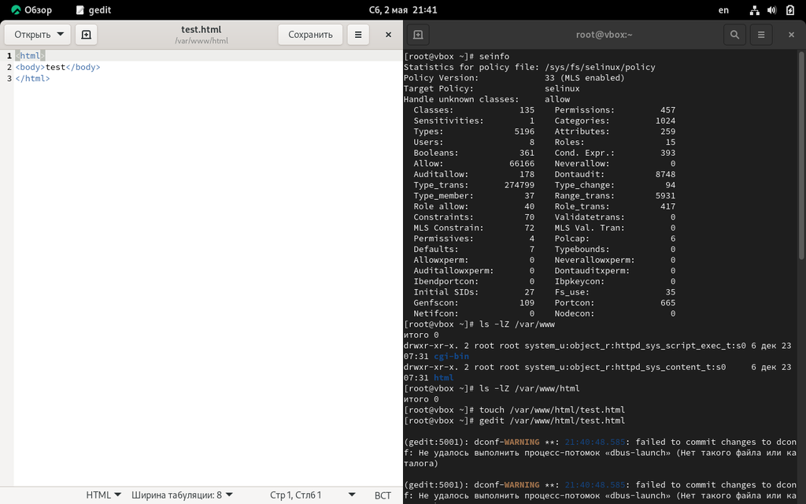

Рисунок 2: Политика SELinux и создание тестового файла

## 9. Контекст по умолчанию для новых файлов

Созданному файлу автоматически присвоен контекст: - **Пользователь SELinux:** `unconfined_u` (для пользователей CentOS, не ограниченных специальными ролями) - **Роль:** `object_r` (стандартная роль для файлов на постоянных носителях) - **Тип:** `httpd_sys_content_t` — именно этот тип позволяет Apache читать файл.

## 10. Доступ к файлу через браузер

Файл успешно отобразился в браузере благодаря типу `httpd_sys_content_t`, который разрешает httpd доступ на чтение.

## 11. Справка man httpd_selinux

Согласно справочной документации, для httpd определены различные типы контекстов: для обычного контента, для CGI-скриптов, для логов и т.д. Тип файла `test.html` соответствует `httpd_sys_content_t` — стандартному типу для статического веб-контента.

## 12. Изменение контекста файла

При изменении контекста файла на `samba_share_t` (тип, предназначенный для файлов Samba) доступ к файлу через браузер стал невозможен. Сервер вернул ошибку **Forbidden**, несмотря на то, что стандартные права доступа (чтение для всех) позволяли читать файл. Это произошло потому, что SELinux блокирует доступ: процесс httpd не имеет права читать файлы с типом `samba_share_t`.

[figure not shown]

Рисунок 3: Ошибка чтения

## 13. Анализ логов

В системных логах (`/var/log/messages`) и логах аудита (`/var/log/audit/audit.log`) появились записи о запрете доступа SELinux. Это подтверждает, что блокировка произведена именно SELinux, а не файловыми правами.

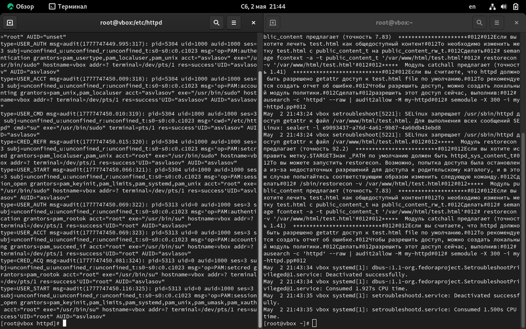

Рисунок 4: Логи ошибки

## 17. Восстановление доступа к файлу

После возврата контексту файла `test.html` исходного типа `httpd_sys_content_t` и обращения к веб-серверу на порту 81 файл снова стал доступен и правильно отобразился в браузере.

## 18. Возврат исходных настроек

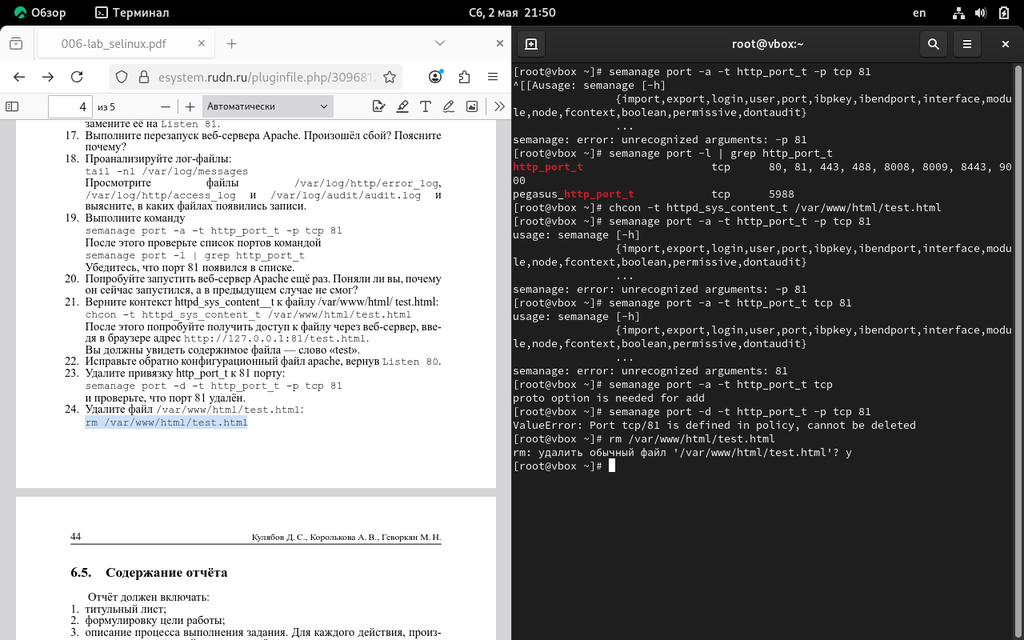

Рисунок 5: Порт 81

## Вывод

В ходе работы наглядно продемонстрирована работа SELinux в режиме enforcing. Показано, что доступ к файлам и сетевым портам для Apache регулируется не только стандартными правами Linux, но и контекстами типов SELinux. Изменение типа файла или попытка использовать неразрешенный порт приводят к блокировке работы сервера, что является важным механизмом защиты системы от несанкционированного доступа и ошибок конфигурации.